# Opioid Usage

Bernes Karacay, Binu Thomas, Davis Thrailkill

December 11, 2018

## Overdoses

- Used the dataset **NCHS - Drug Poisoning Mortality by State: United States** from data.cms.gov
- Gives data per State & Year (1999-2016), which includes: the number of Deaths, Population (in 100,000), Crude Death Rate
- The data is not specific to opioid usage.

### Drug Overdose Mortality by State

#### Rate Change from 2013 to 2016

The states are ordered based on the 2013 death rate. The states with the greatest rate of change in the four year timespan are in bold.

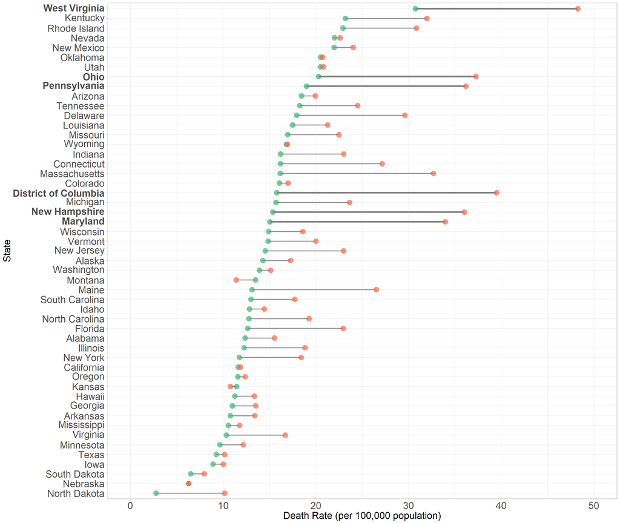

### Drug Overdose Mortality by State

#### Rate Change from 1999 to 2016

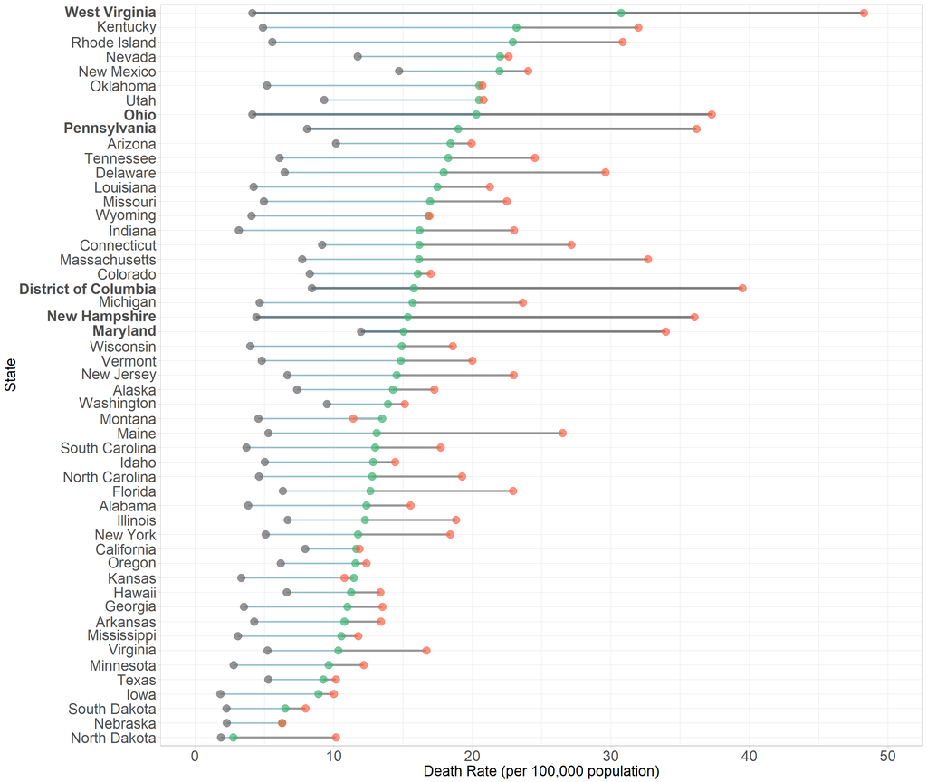

## Opioid Usage

- Used the dataset **Part D Prescriber State Summary Report**, CY2013-16 from data.cms.gov
- Gives data per State and Drug (& Generic) Name, including: the number of Prescribers, number of Claims, Opioid Drug Flag

### Number of Opioid Types (by Generic Name) Prescribed in each State

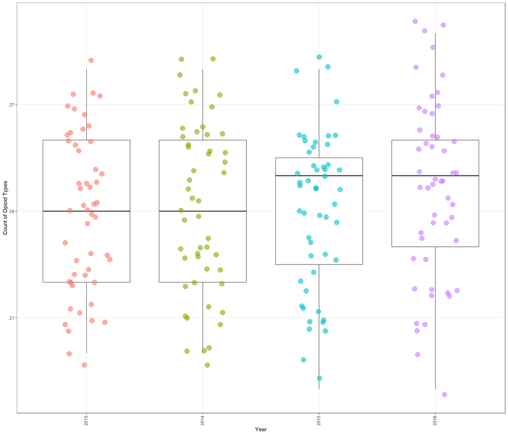

### Opioid Usage

#### Most Prescribed Opioids in 2016

We chose to specifically look at the top seven opioids prescribed (as a percentage of all opioids prescribed) for five states with the highest overdose death rates in 2016 and to see how that data trended starting in 2013.

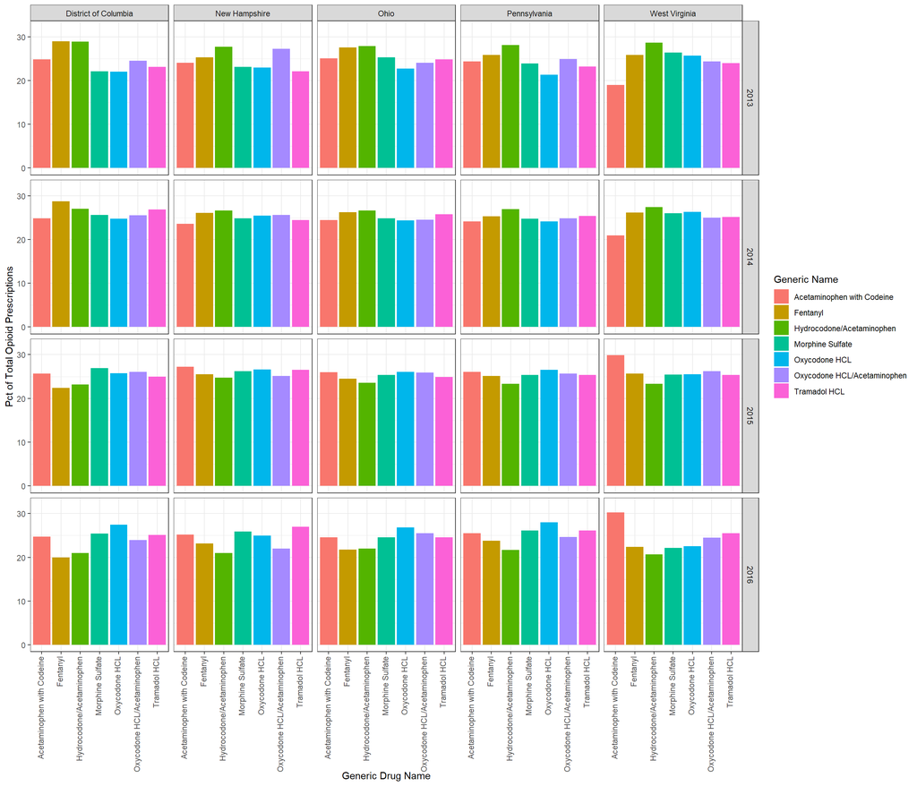

## Opioid Usage: Prescriber Level

- In place of the “Prescriber Info” data, used the dataset **Medicare Provider Utilization and Payment Data: Part D Prescriber Summary Table** for CY2013-16 from data.cms.gov
- Gives the following data for each NPI:
- State, Specialty, Total Claim Count, Opioid Claim Count, Opioid Prescriber Rate, Opioid Day Supply, Average Age of Beneficiaries, Beneficiary Gender, Beneficiary Race, Beneficiary Avg Risk Score
- Subset this based on NPIs in original ’Presiber Info" dataset

### Opioid Prescription Rate per State

#### 2013-2016

Across the country, physicians prescribed opioids at lower rates in 2016 than they did in 2013. During the same timespan, overdoses due to opioid abuse increased rapidly. We decided to examine if specialty had an effect on prescribing habits.

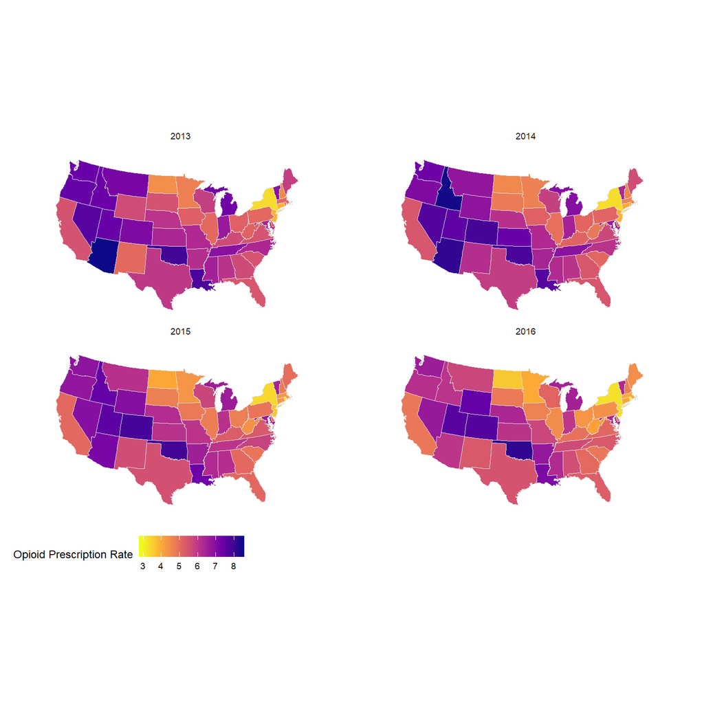

### Total Opioid Claims by Specialty

#### Nationally, 2013-2016

Family Practice, Internal Medicine, Nurse Practitioner, Physician Assistant, and Orthopedic Surgery are the top five specialties by total opioid claims.

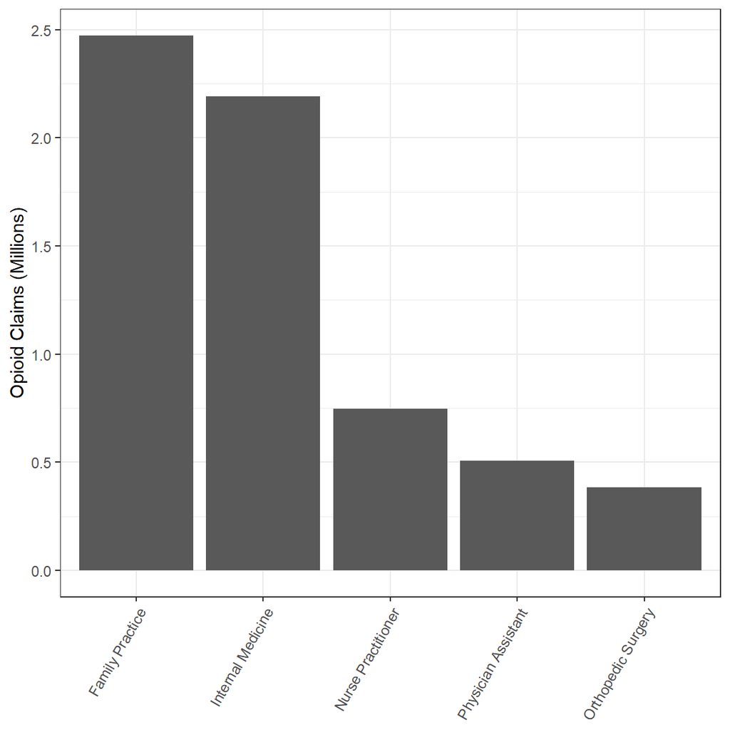

### Opioid Prescription Rate by Specialty per Year

#### Nationally, 2013-2016

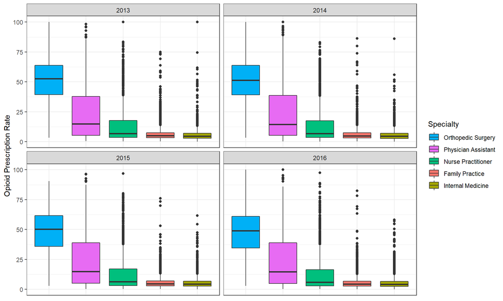

### Opioid Prescriptions by Specialty

#### Nationally, 2013-2016

The grid below shoes the total opioid claims and the prescription rates per year for the top five specialties in terms of opioid claims.

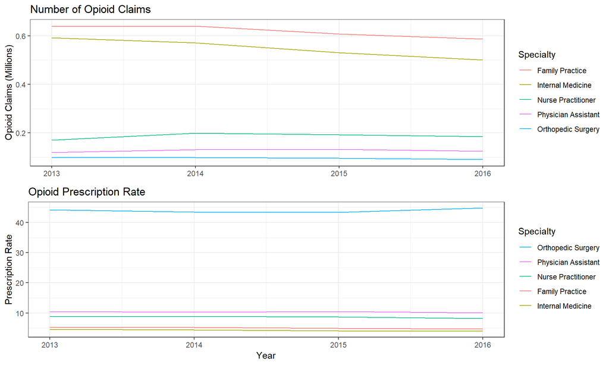

### Opioid Prescription Rate by Specialty

#### Nationally, 2013-2016

Pain Management, Anesthesiology, Interventional Pain Management, Physical Medicine and Rehabilitation, and Orthopedic Surgery are the top five specialties by opioid prescription rate, defined as the ratio of opioid claims to total claims.

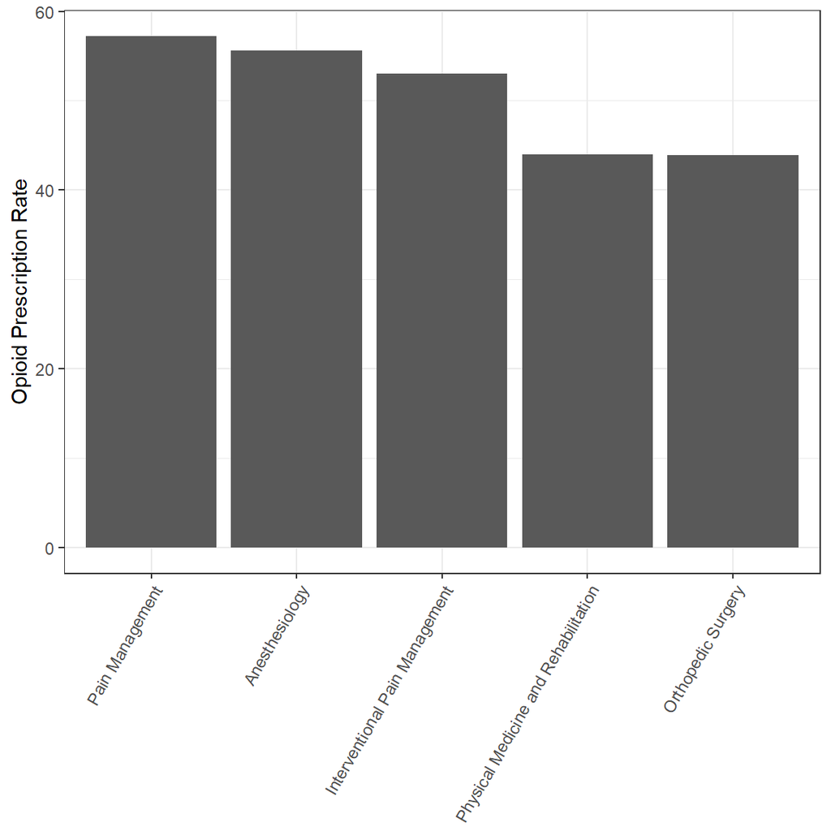

### Opioid Prescription Rate by Specialty per Year

#### Nationally, 2013-2016

In general, we know that physicians prescribed fewer opioids in 2016 than they did in 2013. However, the total prescription rate for four of the below specialties was actually higher in 2016 than in 2013.

Here, each dot represents a physician and is colored by specialty.

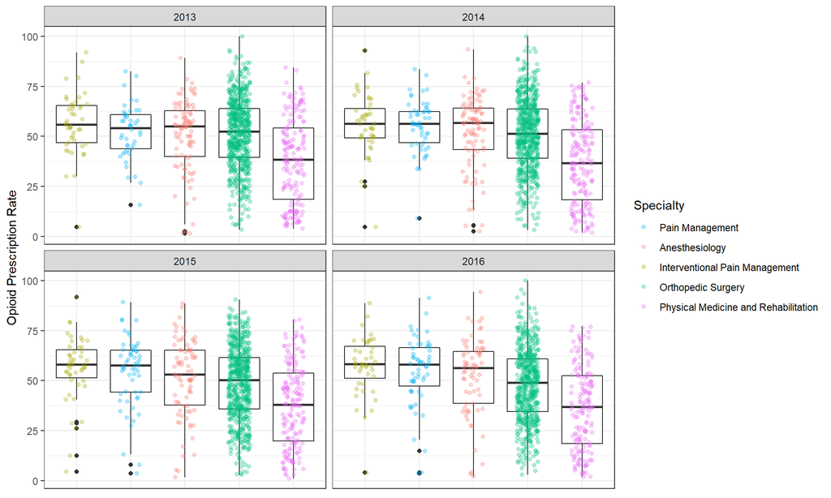

### Opioid Prescriptions by Specialty

#### Nationally, 2013-2016

The grid below shows the total opioid claims and the prescription rates per year for the top five specialties in terms of prescription rate. Physical Medicine and Rehabilitation is the only specialty prescribed less in 2016 than in 2013.

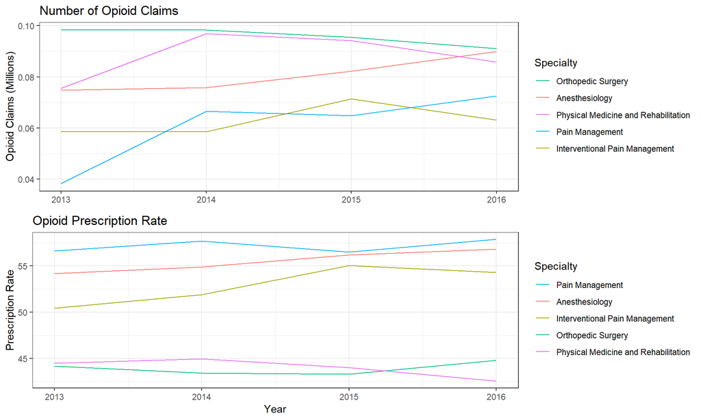

## Pareto Analysis

### Q2 Pareto: top 20 percent of the prescribers provide 80% of the opioid in 2013

- Top **28.65** percent of the prescribers provide 80% of the opioid in 2013.
- Top **28.21** percent of the prescribers provide 80% of the opioid in 2014.
- Top **28.6** percent of the prescribers provide 80% of the opioid in 2015.
- Top **28.49** percent of the prescribers provide 80% of the opioid in 2016.

### Prescribers in top 20 for every years between 2013 to 2016

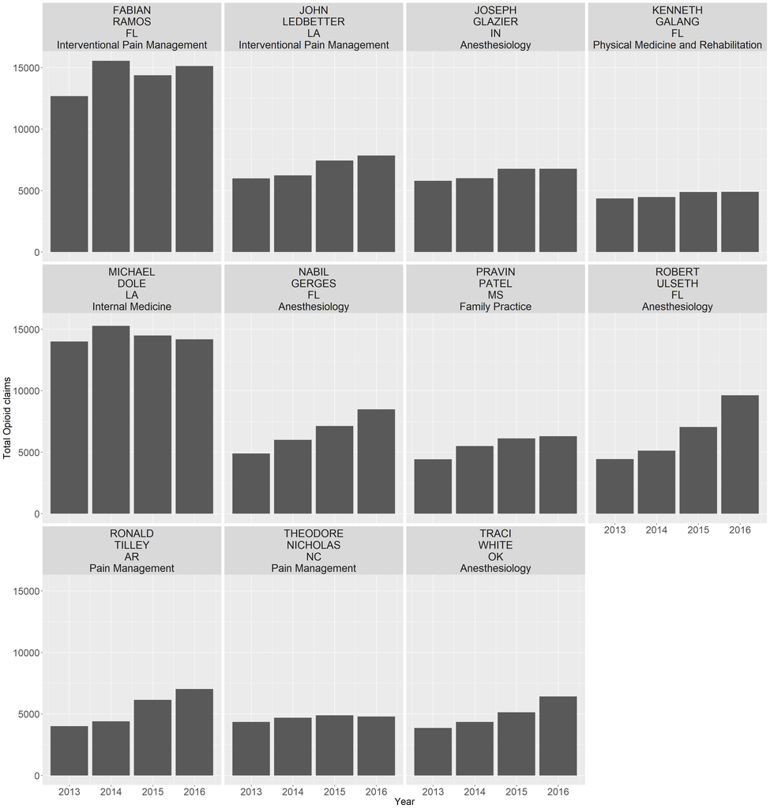

### Regression Outputs

- Linear regression model use in all models.
- We could not utilize mixed or fixed effect regression since we only have four years for each state.
- Dependent variables is always crude death rate.

| *Coefficients* | *Response* |  |  |  |  |  |  |  |  |  |
| --- | --- | --- | --- | --- | --- | --- | --- | --- | --- | --- |
|  |  |  | Estimate | std. Error |  | Estimate | std. Error |  | Estimate | std. Error |
| Constant |  | 131.245 *** | 28.23 |  | 20.878 *** | 2.21 |  | 21.347 *** | 3.11 |  |
| Opioid Prescription Rate |  | -1.102 ** | 0.38 |  | -0.657 | 0.38 |  | -0.680 | 0.40 |  |
| Average Age |  | -1.563 *** | 0.40 |  |  |  |  |  |  |  |
| White Other Race Ratio |  |  |  |  | 0.003 | 0.01 |  |  |  |  |
| GDP per capita |  |  |  |  |  |  |  | -0.000 | 0.00 |  |
| Observations |  | 204 |  |  | 204 |  |  | 204 |  |  |
| R<sup>2</sup> / adj. R<sup>2</sup> |  | .085 / .076 |  |  | .015 / .005 |  |  | .015 / .005 |  |  |
| Notes | * p<.05 ** p<.01 *** p<.001 |  |  |  |  |  |  |  |  |  |

| *Coefficients* | *Response* |  |  |  |  |  |  |
| --- | --- | --- | --- | --- | --- | --- | --- |
|  |  |  | Estimate | std. Error |  | Estimate | std. Error |
| Constant |  | 134.068 *** | 28.99 |  | 127.211 *** | 27.27 |  |
| Opioid Prescription Rate |  | -1.135 ** | 0.40 |  | -1.332 *** | 0.38 |  |
| Average Age |  | -1.595 *** | 0.41 |  | -2.037 *** | 0.39 |  |
| White Other Race Ratio |  | -0.005 | 0.01 |  | -0.008 | 0.01 |  |
| GDP per capita |  | -0.000 | 0.00 |  | -0.000 | 0.00 |  |
| Male Female Ratio |  |  |  |  | 59.022 *** | 11.26 |  |
| Observations |  | 204 |  |  | 204 |  |  |
| R<sup>2</sup> / adj. R<sup>2</sup> |  | .086 / .067 |  |  | .197 / .177 |  |  |
| Notes | * p<.05 ** p<.01 *** p<.001 |  |  |  |  |  |  |